# DDS Breweries Case Study

CJ & JW

2023-10-20

#Introduction Budweiser tasked us with answering questions regarding US beers and breweries. Budweiser gave us two data sets; one containing the data of 558 breweries and another containing the data of 2410 beers.

The data contained all relevant information needed to answer the proposed questions. Some of the data included were brewery location, ABV, IBU and style of Beer.

We were able to to clean, prep, merge, transform and visualize the data to appropriately answer all questions from Budweiser.

#Load in required libraries.

```r
library (ggplot2)
library (dplyr)
library(tidyverse)
```

#Load in required data.

```r
brew=read.csv("/Users/christopherjohnson/Downloads/Breweries.csv",header = TRUE)
beer=read.csv("/Users/christopherjohnson/Downloads/Beers.csv",header = TRUE)
head(brew)
```

```
##   Brew_ID                      Name          City State
## 1       1        NorthGate Brewing    Minneapolis    MN
## 2       2 Against the Grain Brewery    Louisville    KY
## 3       3  Jack's Abby Craft Lagers    Framingham    MA
## 4       4 Mike Hess Brewing Company     San Diego    CA
## 5       5   Fort Point Beer Company San Francisco    CA
## 6       6     COAST Brewing Company    Charleston    SC
```

```r
head(beer)
```

```
##                  Name Beer_ID   ABV IBU Brewery_id
## 1            Pub Beer    1436 0.050  NA        409
## 2         Devil's Cup    2265 0.066  NA        178
## 3 Rise of the Phoenix    2264 0.071  NA        178
## 4            Sinister    2263 0.090  NA        178
## 5       Sex and Candy    2262 0.075  NA        178
## 6        Black Exodus    2261 0.077  NA        178
##                            Style Ounces
## 1            American Pale Lager     12
## 2        American Pale Ale (APA)     12
## 3                   American IPA     12
## 4 American Double / Imperial IPA     12
## 5                   American IPA     12
## 6                  Oatmeal Stout     12
```

#Use the group_by function to group states together and count number of breweries in each state.

```r
brew2 = brew %>%
  group_by(State) %>%
  summarize(Brewery_Count = n())
print(brew2, n=100)
```

```
## # A tibble: 51 × 2
##    State Brewery_Count
##    <chr>         <int>
##  1 " AK"             7
##  2 " AL"             3
##  3 " AR"             2
##  4 " AZ"            11
##  5 " CA"            39
##  6 " CO"            47
##  7 " CT"             8
##  8 " DC"             1
##  9 " DE"             2
## 10 " FL"            15
## 11 " GA"             7
## 12 " HI"             4
```

[output cut: 39 more lines]

1. How many breweries are present in each state? The breweries are present in each states with different counts. For example, AK has 7 breweries, AL has 3, AZ has 11, CA has 39, CO has 47, and so on. We also showed a bar graph of the counts from least to greatest. #Use ggplot to plot the number of breweries per State.

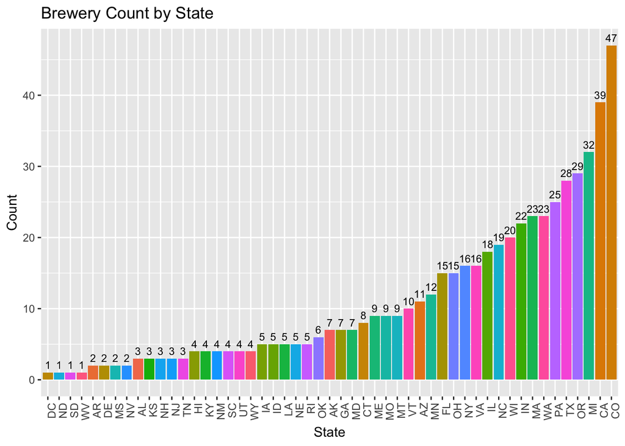

```r
ggplot(data = brew2, aes(x = reorder(State,Brewery_Count) ,y = Brewery_Count,fill=State))+
  geom_bar(stat = "identity") +
  labs(title = "Brewery Count by State", x = "State", y = "Count")+
  geom_text(aes(label = Brewery_Count), vjust = -0.5, size = 3)+
  theme(axis.text.x = element_text(angle = 90, hjust = 1), legend.position = "none")
```

```r
brew$Brewery_id=brew$Brew_ID
brew=brew[,-1] ###remove old column name
head(brew)
```

```
##                        Name          City State Brewery_id
## 1        NorthGate Brewing    Minneapolis    MN          1
## 2 Against the Grain Brewery    Louisville    KY          2
## 3  Jack's Abby Craft Lagers    Framingham    MA          3
## 4 Mike Hess Brewing Company     San Diego    CA          4
## 5   Fort Point Beer Company San Francisco    CA          5
## 6     COAST Brewing Company    Charleston    SC          6
```

```r
bdf=merge(x=beer, y=brew, by="Brewery_id",all=TRUE) ##merge columns
head(bdf)
```

```
##   Brewery_id        Name.x Beer_ID   ABV IBU
## 1          1  Get Together    2692 0.045  50
## 2          1 Maggie's Leap    2691 0.049  26
## 3          1    Wall's End    2690 0.048  19
## 4          1       Pumpion    2689 0.060  38
## 5          1    Stronghold    2688 0.060  25
## 6          1   Parapet ESB    2687 0.056  47
##                                 Style Ounces             Name.y        City
## 1                        American IPA     16 NorthGate Brewing  Minneapolis
## 2                  Milk / Sweet Stout     16 NorthGate Brewing  Minneapolis
## 3                   English Brown Ale     16 NorthGate Brewing  Minneapolis
## 4                         Pumpkin Ale     16 NorthGate Brewing  Minneapolis
## 5                     American Porter     16 NorthGate Brewing  Minneapolis
## 6 Extra Special / Strong Bitter (ESB)     16 NorthGate Brewing  Minneapolis
##   State
## 1    MN
## 2    MN
## 3    MN
## 4    MN
## 5    MN
## 6    MN
```

# Gives you the missing values and percentage in each coloum (naniar package)

```r
library(naniar)
miss_var_summary(bdf)
```

```
## # A tibble: 10 × 3
##    variable   n_miss pct_miss
##    <chr>       <int>    <dbl>
##  1 IBU          1005    41.7
##  2 ABV            62     2.57
##  3 Brewery_id      0     0
##  4 Name.x          0     0
##  5 Beer_ID         0     0
##  6 Style           0     0
##  7 Ounces          0     0
##  8 Name.y          0     0
##  9 City            0     0
## 10 State           0     0
```

3. Address the missing values in each column. We found missing values in the dataset. For instance, the IBU column had 1005 missing values, which is 41.7% of the column in the data. The ABV column had 62 missing values, which is 2.57% of that column. We then found the median IBU and ABV for each state. Once we found the median value by state, we ran and ifelse loop to replace any missing values with their states corresponding value

#Find the median ABV and IBU by state. Any row missing ABV or IBU is replaced by its corresponding States median value. Remove extra columns and create new data frame.

```r
abv_median = aggregate(ABV ~ State, data = bdf, FUN = function(x) median(as.numeric(x), na.rm = TRUE))
ibu_median = aggregate(IBU ~ State, data = bdf, FUN = function(x) median(as.numeric(x), na.rm = TRUE))

state_median = merge(ibu_median, abv_median, by = "State", all = TRUE)

bdf2 = merge(bdf, state_median, by = "State", all.x = TRUE)
bdf2$IBU = ifelse(is.na(bdf2$IBU.x), bdf2$IBU.y, bdf2$IBU.x)
bdf2$ABV = ifelse(is.na(bdf2$ABV.x), bdf2$ABV.y, bdf2$ABV.x)
bdf3 = bdf2[, -c(5, 6,11,12)]  # Remove redundant columns
```

#Convert ABV from decimal to percentage

```r
bdf3$ABV=bdf3$ABV*100
```

#Change Beer and Brewery column names from the names assigned when merged. Remove old column names.

```r
bdf3$Beer_Name=bdf3$Name.x
bdf3$Brewery_Name=bdf3$Name.y
bdf4=bdf3[,-c(3,7)]
head(bdf4)
```

```
##   State Brewery_id Beer_ID                    Style Ounces      City IBU ABV
## 1    AK        103    1667             American IPA     12 Anchorage  70 6.0
## 2    AK        103    2436 American Amber / Red Ale     12 Anchorage  46 5.1
## 3    AK        494     920  American Pale Ale (APA)     12 Anchorage  17 5.2
## 4    AK        459     349             American IPA     12  Soldotna  46 6.8
## 5    AK        103    1706           Czech Pilsener     12 Anchorage  46 5.5
## 6    AK        459     348             Scottish Ale     12  Soldotna  46 5.8
##                    Beer_Name                 Brewery_Name
## 1            King Street IPA  King Street Brewing Company
## 2                  Amber Ale  King Street Brewing Company
## 3             Polar Pale Ale Broken Tooth Brewing Company
## 4          Sunken Island IPA  Kenai River Brewing Company
## 5        King Street Pilsner  King Street Brewing Company
## 6 Skilak Scottish Ale (2011)  Kenai River Brewing Company
```

#South Dakota had no IBU data to find median from. Assigned all SD beers with median IBU (35) from all States.

```r
bdf4[2003:2009,7]=35
```

#Replacing SD IBU with median of all other states median.

```r
median(ibu_median$IBU)
```

```
## [1] 35
```

```r
state_median[42,2]="35"
```

#Convert IBU to numeric from character.

```r
class(state_median$ABV)
```

```
## [1] "numeric"
```

```r
state_median$IBU=as.numeric(state_median$IBU)
```

4. Compute the median alcohol content and international bitterness unit for each state. Plot a bar chart to compare. The median alcohol content (ABV) and international bitterness unit (IBU) were computed for each state and we visualized them by using bar charts. KY being the highest for ABV and ME being the highest for IBU.

#Plot State median ABV, ascending order and ylim adjusted

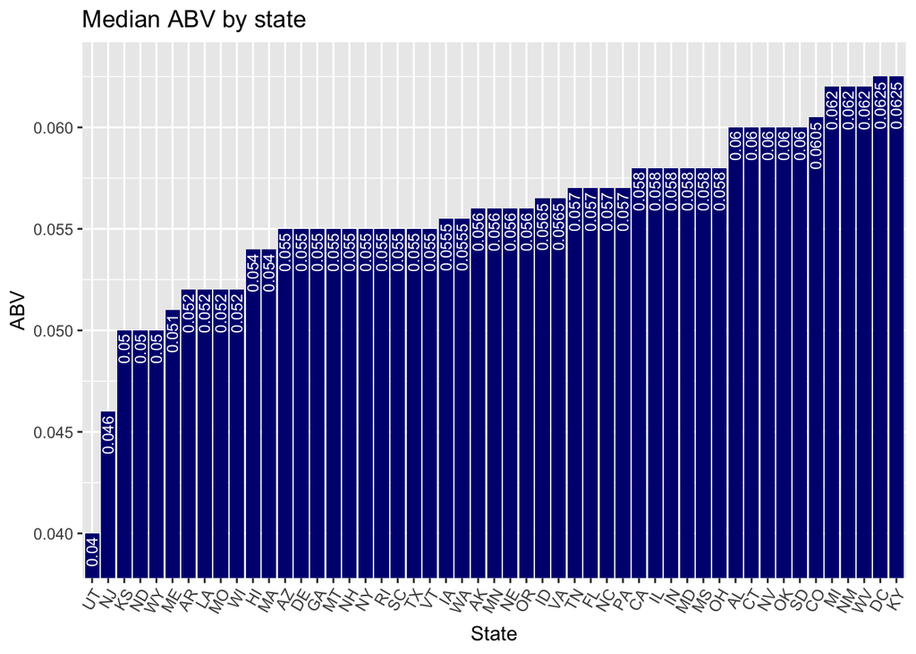

```r
ggplot(data = state_median, aes(x = reorder(State,ABV) ,y = ABV, )) +
  geom_bar(stat = "identity",fill="navyblue")+
  labs(title = "Median ABV by state", x = "State", y = "ABV")+
  geom_text(aes(label = ABV), vjust = .5, hjust=1.1, size = 3, angle=90, color="white")+
  theme(axis.text.x = element_text(angle = 60, hjust = 1), legend.position = "none")+ coord_cartesian(ylim=c(0.039,0.063))
```

#Plot State median IBU, ascending order and ylim adjusted

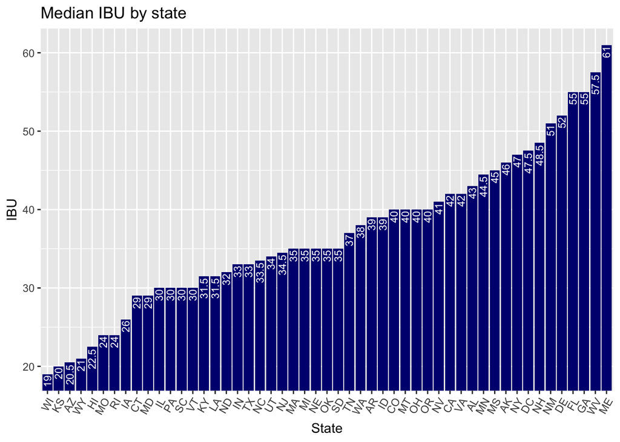

```r
ggplot(data = state_median, aes(x = reorder(State,IBU) ,y = IBU)) +
  geom_bar(stat = "identity",fill="navyblue")+
  labs(title = "Median IBU by state", x = "State", y = "IBU")+
  geom_text(aes(label = IBU), vjust = .5, hjust=1.1, size = 3, angle=90, color="white")+
  theme(axis.text.x = element_text(angle = 60, hjust = 1), legend.position = "none")+ coord_cartesian(ylim=c(19,61))
```

5. Which state has the maximum alcoholic (ABV) beer? Which state has the most bitter (IBU) beer? The state with the maximum alcoholic beer (ABV of 12.8) was Colorado, with the beer “Lee Hill Series Vol. 5 Belgian Style Quadrupel Ale” from Upslope Brewing Company. The state with the most bitter beer (IBU of 138) was Oregon, with the beer “Bitter Bitch Imperial IPA” from Astroia Brewing Company.

#Use the max function to Find highest ABV and IBU then grep function to corresponding row

```r
max(bdf4$ABV)
```

```
## [1] 12.8
```

```r
grep("12.8",bdf4$ABV)
```

```
## [1] 533
```

```r
bdf4[533,]    ########Lee Hill Series Vol. 5 Belgian Style Quadrupel Ale, Upslope Brewing Company, CO
```

```
##     State Brewery_id Beer_ID            Style Ounces    City IBU  ABV
## 533    CO         52    2565 Quadrupel (Quad)   19.2 Boulder  40 12.8
##                                                Beer_Name
## 533 Lee Hill Series Vol. 5 - Belgian Style Quadrupel Ale
##                Brewery_Name
## 533 Upslope Brewing Company
```

```r
max(bdf4$IBU)
```

```
## [1] 138
```

```r
grep("138",bdf4$IBU)
```

```
## [1] 1824
```

```r
bdf4[1824,] #######Bitter Bitch Imperical IPA, Astroia Brewing Company, OR
```

```
##      State Brewery_id Beer_ID                          Style Ounces    City IBU
## 1824    OR        375     980 American Double / Imperial IPA     12 Astoria 138
##      ABV                 Beer_Name            Brewery_Name
## 1824 8.2 Bitter Bitch Imperial IPA Astoria Brewing Company
```

6. Comment on the summary statistics and distribution of the ABV variable. The mean of ABV is about 5.97%. The median ABV is 5.7%. The range of ABV goes from 0.1% to 12.8%. The variance of the ABV is about 1.79, and the standard deviation is approximately 1.34. The histogram is slightly right skew.

#Summary statistics of ABV

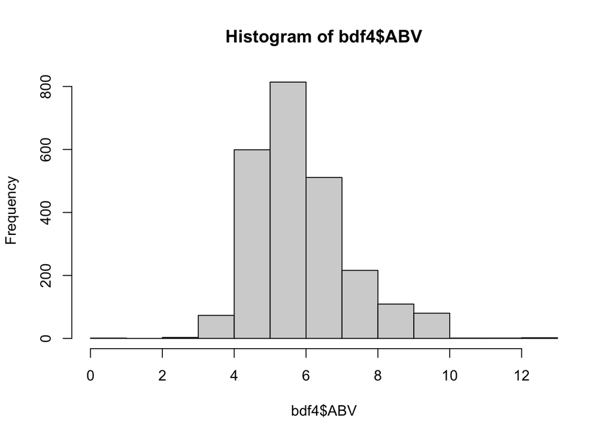

```r
hist(x=bdf4$ABV)
```

```r
value=c(mean(bdf4$ABV),median(bdf4$ABV),range(bdf4$ABV),var(bdf4$ABV),sd(bdf4$ABV))
Statistic=c("Mean", "Median", "Range-Lower","Range-Upper", "Variance", "Standard Deviation")
ssDF=cbind(value,Statistic)
ssDF
```

```
##      value              Statistic
## [1,] "5.97315352697095" "Mean"
## [2,] "5.7"              "Median"
## [3,] "0.1"              "Range-Lower"
## [4,] "12.8"             "Range-Upper"
## [5,] "1.78983521510795" "Variance"
## [6,] "1.33784723160305" "Standard Deviation"
```

```r
summary(bdf4$ABV)
```

```
##    Min. 1st Qu.  Median    Mean 3rd Qu.    Max.
##   0.100   5.000   5.700   5.973   6.700  12.800
```

```r
summary(bdf4$IBU)
```

```
##    Min. 1st Qu.  Median    Mean 3rd Qu.    Max.
##    4.00   26.00   35.00   39.81   47.00  138.00
```

7. Is there an apparent relationship between the bitterness of the beer and its alcoholic content? Draw a scatter plot. Make your best judgment of a relationship and EXPLAIN your answer. We showed the association between IBU and ABV through a scatter plot and doing a best fitted regression line. The graph shows that as ABV increases, IBU is also associated with an upward move. This could possibly mean that beers with greater ABV are often associated with a more bitter flavor due to higher IBU values.

#Use GGPlot to create Scatter plot IBU vs ABV w/ linear line to find relationship

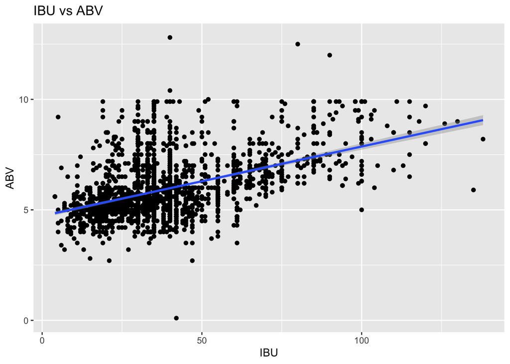

```r
ggplot(bdf4, aes(x = IBU, y = ABV,)) +
  geom_point()+geom_smooth(method = "lm")+
labs(title = "IBU vs ABV", x = "IBU", y = "ABV")
```

# Find ‘IPA’ and ‘Ale’ beers within dataframe

```r
IPA=grep("IPA", bdf4$Style, ignore.case = TRUE)
IPAdf=bdf4[IPA,]

ALE=grep("Ale", bdf4$Style, ignore.case = TRUE)
ALEdf=bdf4[ALE,]
```

#Check for IPA’s in Ale catagory and remove

```r
ALE2=grep("IPA", ALEdf$Style, ignore.case = TRUE)
ALEdf2=ALEdf[ALE2,]

AleDF3=ALEdf[-ALE2,]
```

#Create ‘Type’ column and merge data frames

```r
AleDF3$Type="Ales"
head(AleDF3)
```

```
##    State Brewery_id Beer_ID                    Style Ounces      City IBU ABV
## 2     AK        103    2436 American Amber / Red Ale     12 Anchorage  46 5.1
## 3     AK        494     920  American Pale Ale (APA)     12 Anchorage  17 5.2
## 6     AK        459     348             Scottish Ale     12  Soldotna  46 5.8
## 12    AK        558      30         English Pale Ale     12 Anchorage  46 4.9
## 13    AK        271    1921  American Pale Ale (APA)     12    Juneau  40 5.3
## 15    AK        494     919                Cream Ale     12 Anchorage  46 4.8
##                     Beer_Name                  Brewery_Name Type
## 2                   Amber Ale   King Street Brewing Company Ales
## 3              Polar Pale Ale  Broken Tooth Brewing Company Ales
## 6  Skilak Scottish Ale (2011)   Kenai River Brewing Company Ales
## 12  Urban Wilderness Pale Ale Sleeping Lady Brewing Company Ales
## 13               Freeride APA       Alaskan Brewing Company Ales
## 15        Chugach Session Ale  Broken Tooth Brewing Company Ales
```

```r
IPAdf$Type="IPA"
head(IPAdf)
```

```
##    State Brewery_id Beer_ID        Style Ounces      City IBU ABV
## 1     AK        103    1667 American IPA     12 Anchorage  70 6.0
## 4     AK        459     349 American IPA     12  Soldotna  46 6.8
## 7     AK        224     434 American IPA     12 Anchorage  70 5.7
## 10    AK        224    1814 American IPA     12 Anchorage  61 6.3
## 14    AK        494     648 American IPA     12 Anchorage  64 6.1
## 19    AK        224    2093 American IPA     12 Anchorage  61 6.3
##            Beer_Name                 Brewery_Name Type
## 1    King Street IPA  King Street Brewing Company  IPA
## 4  Sunken Island IPA  Kenai River Brewing Company  IPA
## 7    Sockeye Red IPA Midnight Sun Brewing Company  IPA
## 10 Pleasure Town IPA Midnight Sun Brewing Company  IPA
## 14   Fairweather IPA Broken Tooth Brewing Company  IPA
## 19     Pleasure Town Midnight Sun Brewing Company  IPA
```

```r
merge_type=rbind(IPAdf, AleDF3)
tail(merge_type)
```

```
##      State Brewery_id Beer_ID                    Style Ounces     City IBU ABV
## 2401    WY         80    2484 American Amber / Red Ale     12 Sheridan  20 4.6
## 2403    WY        551     324  American Pale Ale (APA)     16 Pinedale  21 7.2
## 2405    WY        458    1198        English Brown Ale     12 Sheridan  16 4.8
## 2407    WY        192    1606  American Pale Ale (APA)     12  Jackson  55 6.0
## 2408    WY        458    1197  American Pale Wheat Ale     12 Sheridan  15 5.9
## 2410    WY        458    1200 American Amber / Red Ale     12 Sheridan  20 4.6
##                             Beer_Name                    Brewery_Name Type
## 2401        Bomber Mountain Amber Ale     Black Tooth Brewing Company Ales
## 2403                 Wyoming Pale Ale      Wind River Brewing Company Ales
## 2405    Saddle Bronc Brown Ale (2013) The Black Tooth Brewing Company Ales
## 2407               Snow King Pale Ale     Snake River Brewing Company Ales
## 2408             Wagon Box Wheat Beer The Black Tooth Brewing Company Ales
## 2410 Bomber Mountain Amber Ale (2013) The Black Tooth Brewing Company Ales
```

#Scale ABV and IBU for KNN

```r
merge_type$sIBU=scale(merge_type$IBU)
merge_type$sABV=scale(merge_type$ABV)
```

#Split data into test/train groups 70/30

```r
library(caret)
set.seed(3)
train_index=createDataPartition(merge_type$Type, p = 0.7, list = FALSE)
training_data = merge_type[train_index, ]
testing_data = merge_type[-train_index, ]
testing_data
```

[output not shown]

[output cut: 1407 more lines]

#KNN find best K value for accuracy, Sens(Ales), Spec(IPA) and plot

```r
set.seed(37)
library(class)
mAcc = matrix(nrow = 100)
mSen = matrix(nrow = 100)
mSpec = matrix(nrow = 100)
for (i in 1:100){
  knn_model = knn(train = training_data[, c("sABV", "sIBU")], test = testing_data[, c("sABV", "sIBU")], cl = training_data$Type, k = i)
  CM = confusionMatrix(table(knn_model,testing_data$Type))
  mAcc[i]=CM$overall[1]
  mSen[i]=CM$byClass[1]
  mSpec[i]=CM$byClass[2]
}
max(mAcc)
```

```
## [1] 0.7991543
```

```r
max(mSen)
```

```
## [1] 0.8807947
```

```r
max(mSpec)
```

```
## [1] 0.6959064
```

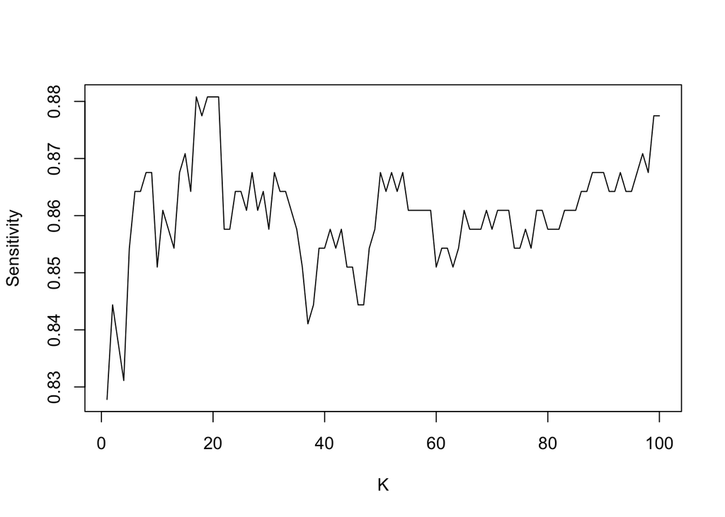

```r
plot(mSen, type = "l", ylab="Sensitivity", xlab="K")
```

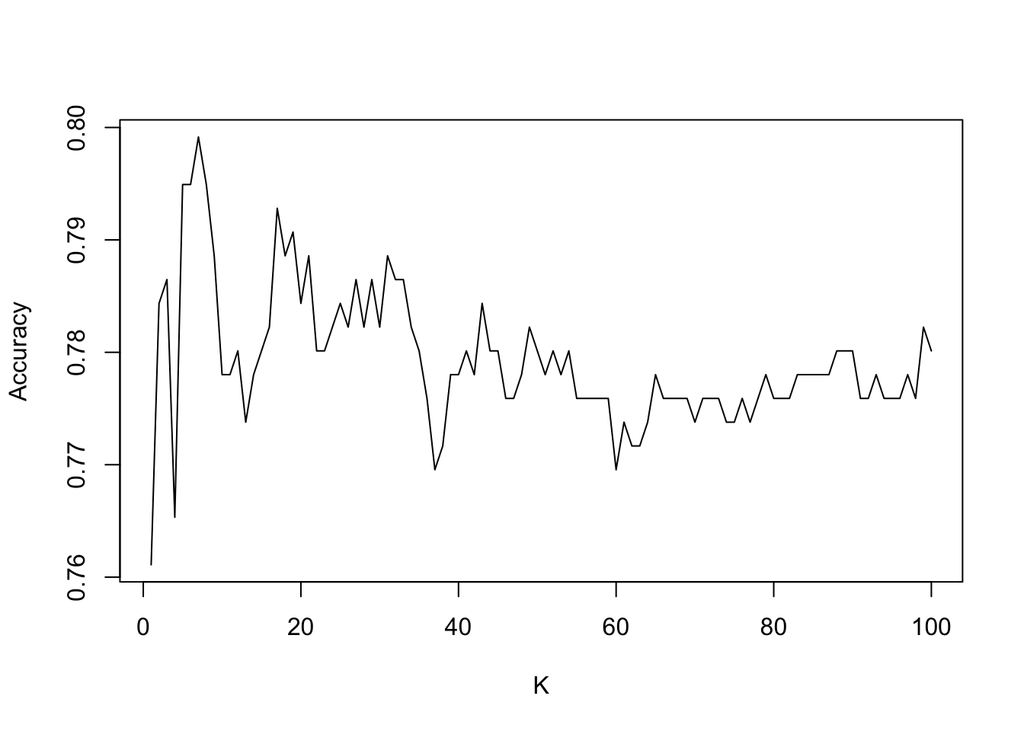

```r
plot(mAcc, type="l", ylab="Accuracy", xlab="K")
```

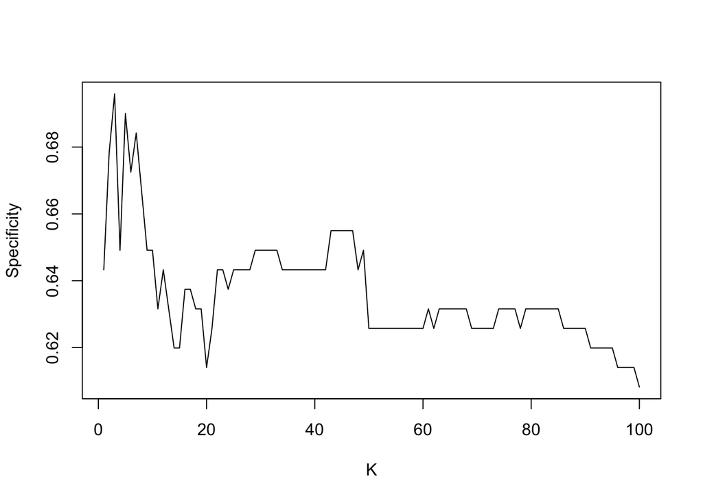

```r
plot(mSpec, type = "l", ylab="Specificity", xlab="K")
```

# Top variety of beers by state and city plotted using ggplot

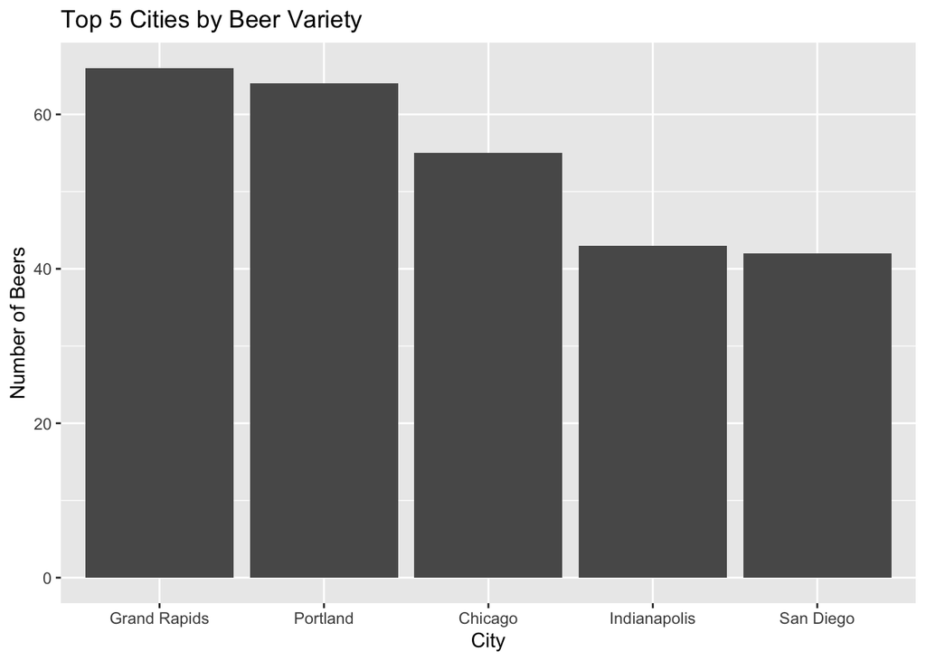

```r
top_cities <- head(sort(table(bdf4$City), decreasing = TRUE), 5)
top_states <- head(sort(table(bdf4$State), decreasing = TRUE), 5)

ggplot(as.data.frame(top_cities), aes(x = Var1, y = Freq)) +
 geom_bar(stat = "identity") +
 labs(title = "Top 5 Cities by Beer Variety", x = "City", y = "Number of Beers")
```

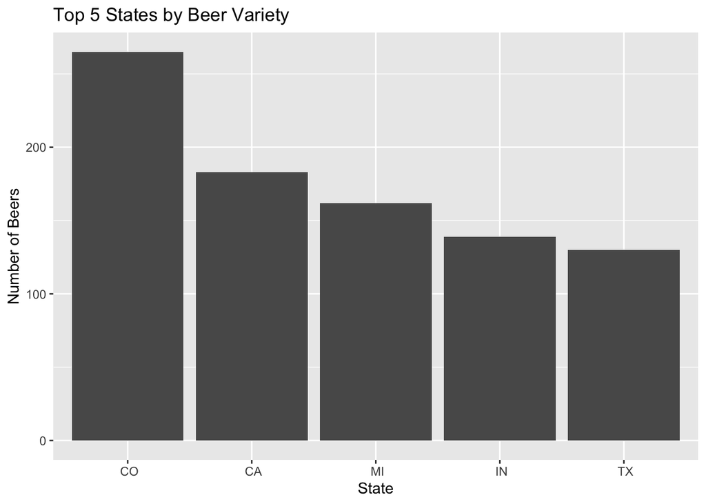

```r
ggplot(as.data.frame(top_states), aes(x = Var1, y = Freq)) +
 geom_bar(stat = "identity") +
 labs(title = "Top 5 States by Beer Variety", x = "State", y = "Number of Beers")
```

#ABV and IBU distribution by beer, plotted using ggplot

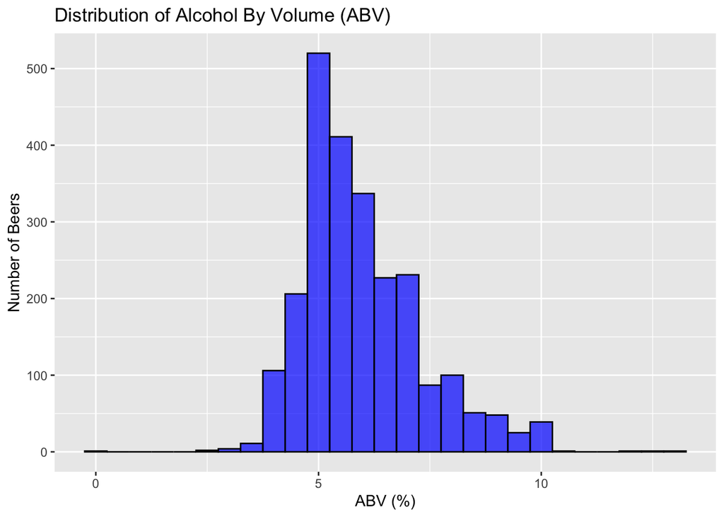

```r
ggplot(bdf4, aes(x = ABV)) +
 geom_histogram(binwidth = 0.5, fill = "blue", color = "black", alpha = 0.7) +
 labs(title = "Distribution of Alcohol By Volume (ABV)", x = "ABV (%)", y = "Number of Beers")
```

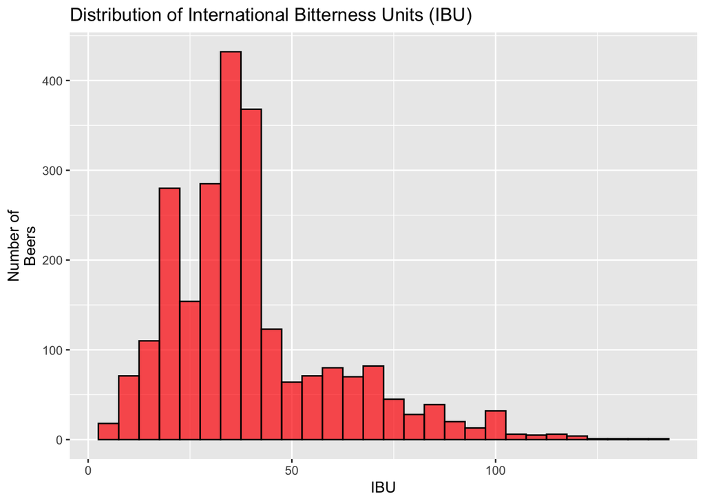

```r
ggplot(bdf4, aes(x = IBU)) +
 geom_histogram(binwidth = 5, fill = "red", color = "black", alpha = 0.7) +
 labs(title = "Distribution of International Bitterness Units (IBU)", x = "IBU", y = "Number of
Beers")
```